# Wine & Dine

### 11.5 — LSTM Baseline: test evaluation

The **test set is used exactly once** here. Loads the best LSTM checkpoint and computes test accuracy, Macro F1, per-class classification report, learning curves, and confusion matrix.

```
  → Loading from VM: weights/lstm_best.pt
LSTM Baseline — Test accuracy : 0.1807  (18.07%)
                Macro F1      : 0.1388

                    precision    recall  f1-score   support

        Sangiovese      0.511     0.025     0.048       907
      Shiraz/Syrah      0.406     0.249     0.308       587
            Merlot      0.183     0.193     0.188       347
        Pinot Noir      0.535     0.551     0.543       303
       Tempranillo      0.163     0.033     0.055       241
         Primitivo      0.190     0.311     0.236       193
Cabernet Sauvignon      0.097     0.105     0.101       162
         Aglianico      0.057     0.272     0.094       114
       Tinta Roriz      0.048     0.028     0.035        72
           Corvina      0.037     0.158     0.060        57
          Nebbiolo      0.133     0.438     0.204        32
    Cabernet Franc      0.066     0.258     0.105        31
     Montepulciano      0.000     0.000     0.000        28
           Barbera      0.043     0.318     0.076        22
        Monastrell      0.016     0.200     0.029        20

          accuracy                          0.181      3116
         macro avg      0.166     0.209     0.139      3116
      weighted avg      0.333     0.181     0.179      3116

  ✓ lstm_curves.png  →  Colab VM + Drive
```

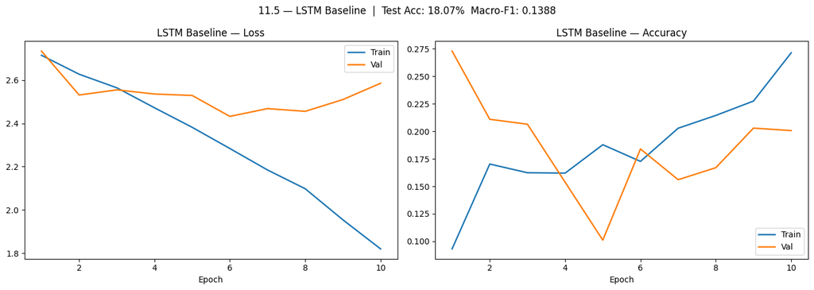

```
  ✓ lstm_cm.png  →  Colab VM + Drive
```

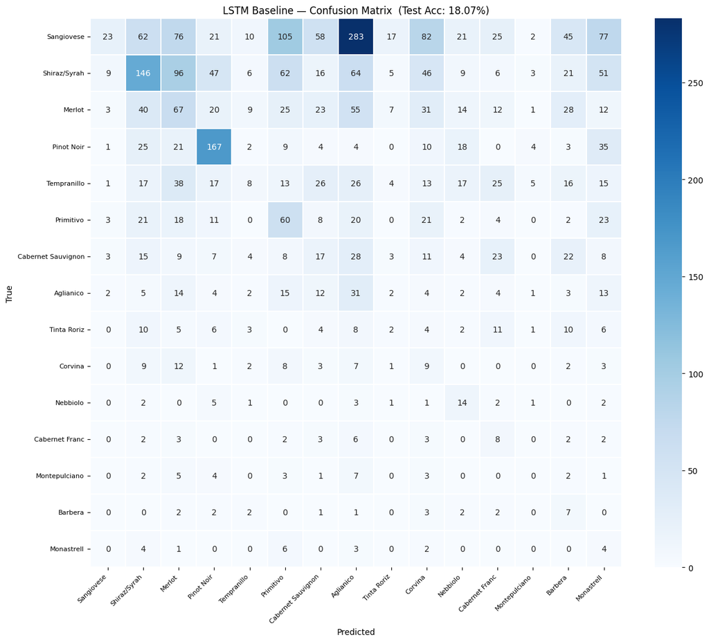

```
✓ 11.5 — LSTM Baseline test evaluation complete.
```

```python
# ── 11.5  LSTM Baseline — test evaluation, curves, confusion matrix ───────────
lstm_model.load_state_dict(load_checkpoint("lstm_best.pt"))
lstm_model.eval()

all_preds_lstm, all_labels_lstm = [], []
with torch.no_grad():
    for seqs, lengths, labels in txt_test_loader:
        logits = lstm_model(seqs.to(DEVICE), lengths.to(DEVICE))
        all_preds_lstm.extend(logits.argmax(1).cpu().tolist())
        all_labels_lstm.extend(labels.tolist())

lstm_test_acc = sum(p == l for p, l in zip(all_preds_lstm, all_labels_lstm)) / len(all_labels_lstm)
lstm_f1       = f1_score(all_labels_lstm, all_preds_lstm, average="macro")
print(f"LSTM Baseline — Test accuracy : {lstm_test_acc:.4f}  ({lstm_test_acc*100:.2f}%)")
print(f"                Macro F1      : {lstm_f1:.4f}")
print()
print(classification_report(all_labels_lstm, all_preds_lstm, target_names=GRAPE_CLASSES, digits=3))

_epochs_lstm = range(1, len(history_lstm["train_loss"]) + 1)
fig, axes = plt.subplots(1, 2, figsize=(14, 5))
axes[0].plot(_epochs_lstm, history_lstm["train_loss"], label="Train", lw=1.8)
axes[0].plot(_epochs_lstm, history_lstm["val_loss"],   label="Val",   lw=1.8)
axes[0].set_title("LSTM Baseline — Loss"); axes[0].set_xlabel("Epoch"); axes[0].legend()
axes[1].plot(_epochs_lstm, history_lstm["train_acc"], label="Train", lw=1.8)
axes[1].plot(_epochs_lstm, history_lstm["val_acc"],   label="Val",   lw=1.8)
axes[1].set_title("LSTM Baseline — Accuracy"); axes[1].set_xlabel("Epoch"); axes[1].legend()
plt.suptitle(f"11.5 — LSTM Baseline  |  Test Acc: {lstm_test_acc*100:.2f}%  Macro-F1: {lstm_f1:.4f}", fontsize=12)
plt.tight_layout()
save_figure(fig, "lstm_curves.png")
plt.show()

lstm_cm = confusion_matrix(all_labels_lstm, all_preds_lstm)
fig, ax = plt.subplots(figsize=(13, 11))
sns.heatmap(lstm_cm, annot=True, fmt="d", cmap="Blues",
            xticklabels=GRAPE_CLASSES, yticklabels=GRAPE_CLASSES, ax=ax, linewidths=0.3)
ax.set_xlabel("Predicted"); ax.set_ylabel("True")
ax.set_title(f"LSTM Baseline — Confusion Matrix  (Test Acc: {lstm_test_acc*100:.2f}%)")
plt.xticks(rotation=45, ha="right", fontsize=8); plt.yticks(fontsize=8)
plt.tight_layout()
save_figure(fig, "lstm_cm.png")
plt.show()
print("✓ 11.5 — LSTM Baseline test evaluation complete.")
```

### 11.6 — Variation 2: Bidirectional LSTM + Bahdanau Attention

**Architecture:**

```
Input (B × L)  →  Embedding (W2V 100-d, fine-tuned)
               →  Dropout(0.4)
               →  BiLSTM (100-d → 256-d × 2, 2 layers)
               →  Bahdanau attention over all L hidden states  →  B × 512
               →  Dropout(0.4)
               →  Linear(512 → 15)
```

**Bahdanau (additive) attention:**

$$\text{score}(h_t) = \mathbf{v}^\top \tanh(\mathbf{W} h_t) \qquad \alpha_t = \text{softmax}(\text{score}) \qquad \mathbf{c} = \sum_t \alpha_t h_t$$

Attention lets the model up-weight grape-discriminative descriptor words (e.g. *tannins* for Cabernet, *tropical fruit* for Viognier) rather than compressing the whole sequence into a single fixed vector.

```python
# ── 11.6  Bidirectional LSTM + Bahdanau Attention ────────────────────────────
class BahdanauAttention(nn.Module):
    def __init__(self, hidden_dim):
        super().__init__()
        self.attn = nn.Linear(hidden_dim * 2, hidden_dim, bias=False)
        self.v    = nn.Linear(hidden_dim,     1,           bias=False)

    def forward(self, hidden_states, mask=None):
        energy  = torch.tanh(self.attn(hidden_states))
        scores  = self.v(energy).squeeze(-1)
        if mask is not None:
            scores = scores.masked_fill(~mask, float("-inf"))
        weights = torch.softmax(scores, dim=1)
        weights = torch.nan_to_num(weights, nan=0.0)
        context = (weights.unsqueeze(-1) * hidden_states).sum(dim=1)
        return context, weights


class BiLSTMAttention(nn.Module):
    def __init__(self, vocab_size, embed_dim, hidden_dim, n_classes,
                 n_layers=2, dropout=0.4, embedding_matrix=None):
        super().__init__()
        self.embedding = nn.Embedding(vocab_size, embed_dim, padding_idx=0)
        if embedding_matrix is not None:
            self.embedding.weight.data.copy_(
                torch.tensor(embedding_matrix, dtype=torch.float32))
        self.lstm = nn.LSTM(embed_dim, hidden_dim, num_layers=n_layers,
                            batch_first=True, bidirectional=True,
                            dropout=dropout if n_layers > 1 else 0.0)
        self.attention = BahdanauAttention(hidden_dim)
        self.drop      = nn.Dropout(dropout)
        self.fc        = nn.Linear(hidden_dim * 2, n_classes)

    def forward(self, x, lengths):
        emb    = self.drop(self.embedding(x))
        packed = pack_padded_sequence(emb, lengths.cpu(),
                                      batch_first=True, enforce_sorted=False)
        output, _ = self.lstm(packed)
        output, _ = pad_packed_sequence(output, batch_first=True, total_length=x.shape[1])
        mask    = (x != 0)
        context, _ = self.attention(output, mask)
        return self.fc(self.drop(context))

    def encode(self, x, lengths):
        emb    = self.embedding(x)
        packed = pack_padded_sequence(emb, lengths.cpu(),
                                      batch_first=True, enforce_sorted=False)
        output, _ = self.lstm(packed)
        output, _ = pad_packed_sequence(output, batch_first=True, total_length=x.shape[1])
        context, _ = self.attention(output, (x != 0))
        return context


bilstm_model = BiLSTMAttention(
    vocab_size=VOCAB_SIZE, embed_dim=EMBED_DIM, hidden_dim=HIDDEN_DIM,
    n_classes=len(GRAPE_CLASSES), n_layers=N_LAYERS, dropout=DROPOUT_RNN,
    embedding_matrix=embedding_matrix,
).to(DEVICE)

_total_bi = sum(p.numel() for p in bilstm_model.parameters())
print(f"BiLSTMAttention — total params : {_total_bi:,}")
_out_bi = bilstm_model(_xb_t.to(DEVICE), _lb_t.to(DEVICE))
assert _out_bi.shape == (TXT_BATCH, len(GRAPE_CLASSES))
print(f"Forward pass  : OK → {_out_bi.shape}")
print("✓ 11.6 — BiLSTMAttention ready.")
```

```
BiLSTMAttention — total params : 2,878,567
Forward pass  : OK → torch.Size([64, 15])
✓ 11.6 — BiLSTMAttention ready.
```

### 11.7 — Training BiLSTM + Attention

Same training protocol as the LSTM Baseline (11.4) — Adam, ReduceLROnPlateau, early stopping (patience 4), gradient clipping, per-epoch Drive checkpoints. Best weights saved to weights/bilstm_best.pt.

```python
# ── 11.7  Train BiLSTM + Attention ───────────────────────────────────────────
opt_bilstm   = Adam(bilstm_model.parameters(), lr=1e-3, weight_decay=1e-5)
sched_bilstm = ReduceLROnPlateau(opt_bilstm, factor=0.5, patience=2)

history_bilstm       = {"train_loss": [], "val_loss": [], "train_acc": [], "val_acc": []}
best_val_loss_bilstm = float("inf")
no_improve_bilstm    = 0
best_ckpt_bilstm     = WEIGHTS / "bilstm_best.pt"

print(f"Training BiLSTMAttention  (max {TXT_EPOCHS} epochs, patience={TXT_PATIENCE})")
print(f"{'Epoch':>5}  {'tr_loss':>8}  {'tr_acc':>7}  {'vl_loss':>8}  {'vl_acc':>7}  {'lr':>9}")
print("-" * 57)

for epoch in range(1, TXT_EPOCHS + 1):
    tr_loss, tr_acc = train_text_epoch(bilstm_model, txt_train_loader, criterion_txt, opt_bilstm)
    vl_loss, vl_acc = eval_text(bilstm_model, txt_val_loader, criterion_txt)
    history_bilstm["train_loss"].append(tr_loss)
    history_bilstm["val_loss"].append(vl_loss)
    history_bilstm["train_acc"].append(tr_acc)
    history_bilstm["val_acc"].append(vl_acc)
    sched_bilstm.step(vl_loss)
    lr_now = opt_bilstm.param_groups[0]["lr"]
    if vl_loss < best_val_loss_bilstm:
        best_val_loss_bilstm = vl_loss
        no_improve_bilstm    = 0
        save_checkpoint(bilstm_model.state_dict(), "bilstm_best.pt")
        marker = " ✓"
    else:
        no_improve_bilstm += 1
        marker = ""
    # ── per-epoch full checkpoint (enables resume after disconnect) ────────────
    save_checkpoint(
        {"epoch": epoch, "model_state": bilstm_model.state_dict(),
         "optimizer_state": opt_bilstm.state_dict(), "val_loss": vl_loss,
         "history": history_bilstm},
        f"bilstm_ckpt_ep{epoch:02d}.pt"
    )
    print(f"{epoch:>5}  {tr_loss:>8.4f}  {tr_acc:>7.4f}  {vl_loss:>8.4f}  {vl_acc:>7.4f}  {lr_now:>9.2e}{marker}")
    if no_improve_bilstm >= TXT_PATIENCE:
        print(f"\nEarly stopping at epoch {epoch}.")
        break

print(f"\nBest val loss : {best_val_loss_bilstm:.4f}  →  {best_ckpt_bilstm}")
print("✓ 11.7 — BiLSTM + Attention training complete.")
```

```
Training BiLSTMAttention  (max 30 epochs, patience=4)
Epoch   tr_loss   tr_acc   vl_loss   vl_acc         lr
---------------------------------------------------------
  ✓ bilstm_best.pt  →  Colab VM + Drive
  ✓ bilstm_ckpt_ep01.pt  →  Colab VM + Drive
    1    2.6561   0.1202    2.5555   0.1364   1.00e-03 ✓
  ✓ bilstm_best.pt  →  Colab VM + Drive
  ✓ bilstm_ckpt_ep02.pt  →  Colab VM + Drive
    2    2.4968   0.1933    2.3839   0.1872   1.00e-03 ✓
  ✓ bilstm_best.pt  →  Colab VM + Drive
  ✓ bilstm_ckpt_ep03.pt  →  Colab VM + Drive
    3    2.3141   0.2336    2.2924   0.2032   1.00e-03 ✓
  ✓ bilstm_best.pt  →  Colab VM + Drive
  ✓ bilstm_ckpt_ep04.pt  →  Colab VM + Drive
    4    2.1650   0.2420    2.2566   0.2578   1.00e-03 ✓
  ✓ bilstm_best.pt  →  Colab VM + Drive
  ✓ bilstm_ckpt_ep05.pt  →  Colab VM + Drive
    5    2.0479   0.2624    2.2448   0.2189   1.00e-03 ✓
  ✓ bilstm_ckpt_ep06.pt  →  Colab VM + Drive
    6    1.9433   0.2952    2.2668   0.2616   1.00e-03
  ✓ bilstm_ckpt_ep07.pt  →  Colab VM + Drive
    7    1.8172   0.3259    2.4063   0.2790   1.00e-03
  ✓ bilstm_ckpt_ep08.pt  →  Colab VM + Drive
    8    1.6813   0.3509    2.4747   0.2565   5.00e-04
  ✓ bilstm_ckpt_ep09.pt  →  Colab VM + Drive
    9    1.5079   0.3862    2.6093   0.2616   5.00e-04

Early stopping at epoch 9.

Best val loss : 2.2448  →  weights/bilstm_best.pt
✓ 11.7 — BiLSTM + Attention training complete.
```

### 11.8 — BiLSTM + Attention: test evaluation

Same evaluation format as 11.5. Loads the best BiLSTM checkpoint and computes test accuracy, Macro F1, per-class classification report, learning curves, and confusion matrix.

```
  → Loading from VM: weights/bilstm_best.pt
BiLSTM+Attention — Test accuracy : 0.2198  (21.98%)
                   Macro F1      : 0.1951

                    precision    recall  f1-score   support

        Sangiovese      0.723     0.198     0.311       907
      Shiraz/Syrah      0.683     0.147     0.241       587
            Merlot      0.450     0.104     0.169       347
        Pinot Noir      0.721     0.323     0.446       303
       Tempranillo      0.565     0.253     0.350       241
         Primitivo      0.267     0.363     0.308       193
Cabernet Sauvignon      0.138     0.167     0.151       162
         Aglianico      0.121     0.298     0.173       114
       Tinta Roriz      0.247     0.278     0.261        72
           Corvina      0.038     0.421     0.069        57
          Nebbiolo      0.082     0.656     0.146        32
    Cabernet Franc      0.083     0.355     0.135        31
     Montepulciano      0.020     0.179     0.036        28
           Barbera      0.048     0.364     0.085        22
        Monastrell      0.025     0.200     0.044        20

          accuracy                          0.220      3116
         macro avg      0.281     0.287     0.195      3116
      weighted avg      0.540     0.220     0.270      3116

  ✓ bilstm_curves.png  →  Colab VM + Drive
```

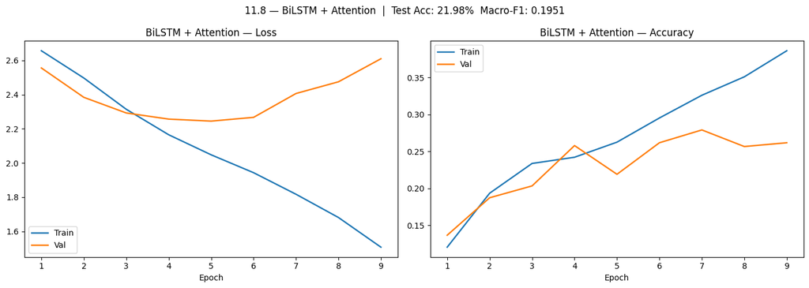

```
  ✓ bilstm_cm.png  →  Colab VM + Drive
```

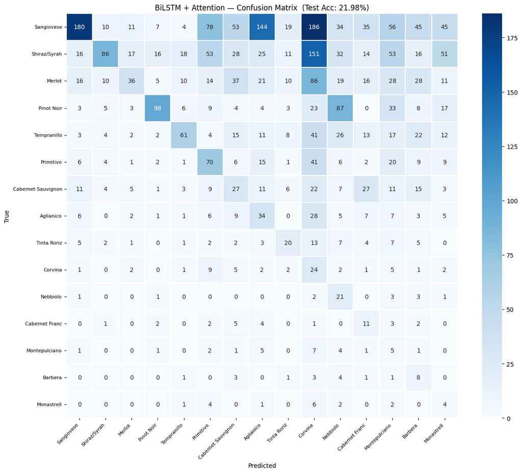

```
✓ 11.8 — BiLSTM + Attention test evaluation complete.
```

```python
# ── 11.8  BiLSTM + Attention — test evaluation, curves, confusion matrix ──────
bilstm_model.load_state_dict(load_checkpoint("bilstm_best.pt"))
bilstm_model.eval()

all_preds_bilstm, all_labels_bilstm = [], []
with torch.no_grad():
    for seqs, lengths, labels in txt_test_loader:
        logits = bilstm_model(seqs.to(DEVICE), lengths.to(DEVICE))
        all_preds_bilstm.extend(logits.argmax(1).cpu().tolist())
        all_labels_bilstm.extend(labels.tolist())

bilstm_test_acc = sum(p == l for p, l in zip(all_preds_bilstm, all_labels_bilstm)) / len(all_labels_bilstm)
bilstm_f1       = f1_score(all_labels_bilstm, all_preds_bilstm, average="macro")
print(f"BiLSTM+Attention — Test accuracy : {bilstm_test_acc:.4f}  ({bilstm_test_acc*100:.2f}%)")
print(f"                   Macro F1      : {bilstm_f1:.4f}")
print()
print(classification_report(all_labels_bilstm, all_preds_bilstm, target_names=GRAPE_CLASSES, digits=3))

_epochs_bi = range(1, len(history_bilstm["train_loss"]) + 1)
fig, axes  = plt.subplots(1, 2, figsize=(14, 5))
axes[0].plot(_epochs_bi, history_bilstm["train_loss"], label="Train", lw=1.8)
axes[0].plot(_epochs_bi, history_bilstm["val_loss"],   label="Val",   lw=1.8)
axes[0].set_title("BiLSTM + Attention — Loss"); axes[0].set_xlabel("Epoch"); axes[0].legend()
axes[1].plot(_epochs_bi, history_bilstm["train_acc"], label="Train", lw=1.8)
axes[1].plot(_epochs_bi, history_bilstm["val_acc"],   label="Val",   lw=1.8)
axes[1].set_title("BiLSTM + Attention — Accuracy"); axes[1].set_xlabel("Epoch"); axes[1].legend()
plt.suptitle(f"11.8 — BiLSTM + Attention  |  Test Acc: {bilstm_test_acc*100:.2f}%  Macro-F1: {bilstm_f1:.4f}", fontsize=12)
plt.tight_layout()
save_figure(fig, "bilstm_curves.png")
plt.show()

bilstm_cm = confusion_matrix(all_labels_bilstm, all_preds_bilstm)
fig, ax   = plt.subplots(figsize=(13, 11))
sns.heatmap(bilstm_cm, annot=True, fmt="d", cmap="Blues",
            xticklabels=GRAPE_CLASSES, yticklabels=GRAPE_CLASSES, ax=ax, linewidths=0.3)
ax.set_xlabel("Predicted"); ax.set_ylabel("True")
ax.set_title(f"BiLSTM + Attention — Confusion Matrix  (Test Acc: {bilstm_test_acc*100:.2f}%)")
plt.xticks(rotation=45, ha="right", fontsize=8); plt.yticks(fontsize=8)
plt.tight_layout()
save_figure(fig, "bilstm_cm.png")
plt.show()
print("✓ 11.8 — BiLSTM + Attention test evaluation complete.")
```

### 11.9 — Comparison: LSTM Baseline vs. BiLSTM + Attention

Produces:

1. **4-panel training curves** — both models side-by-side
2. **Per-class accuracy bar chart** — which grape varieties each model handles better
3. **Summary table** — test accuracy, Macro F1, parameter count

```
=================================================================
Model                          Test Acc    Macro F1      Params
-----------------------------------------------------------------
LSTM Baseline                    18.07%      0.1388   1,326,183
BiLSTM + Attention               21.98%      0.1951   2,878,567
=================================================================
  ✓ rnn_comparison.png  →  Colab VM + Drive
```

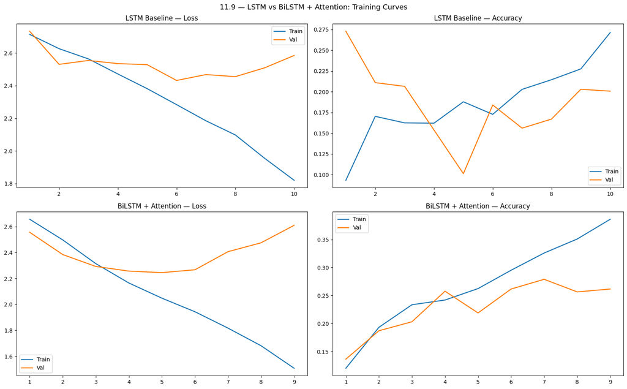

```
  ✓ rnn_per_class.png  →  Colab VM + Drive
```

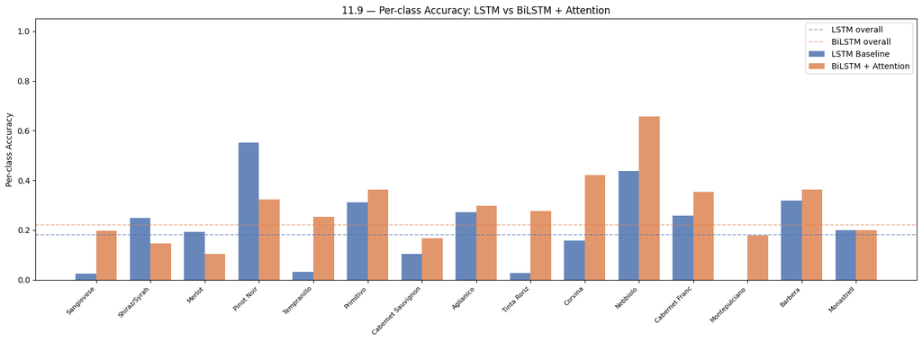

```
✓ 11.9 — LSTM vs BiLSTM + Attention comparison complete.
```

```python
# ── 11.9  Side-by-side comparison: LSTM vs BiLSTM + Attention ────────────────
_lstm_params   = sum(p.numel() for p in lstm_model.parameters())
_bilstm_params = sum(p.numel() for p in bilstm_model.parameters())

print("=" * 65)
print(f"{'Model':<28} {'Test Acc':>10}  {'Macro F1':>10}  {'Params':>10}")
print("-" * 65)
print(f"{'LSTM Baseline':<28} {lstm_test_acc*100:>9.2f}%  {lstm_f1:>10.4f}  {_lstm_params:>10,}")
print(f"{'BiLSTM + Attention':<28} {bilstm_test_acc*100:>9.2f}%  {bilstm_f1:>10.4f}  {_bilstm_params:>10,}")
print("=" * 65)

# ── 4-panel training curves ───────────────────────────────────────────────────
e1 = range(1, len(history_lstm["train_loss"]) + 1)
e2 = range(1, len(history_bilstm["train_loss"]) + 1)
fig, axes = plt.subplots(2, 2, figsize=(16, 10))
axes[0,0].plot(e1, history_lstm["train_loss"], label="Train", lw=1.8)
axes[0,0].plot(e1, history_lstm["val_loss"],   label="Val",   lw=1.8)
axes[0,0].set_title("LSTM Baseline — Loss"); axes[0,0].legend()
axes[0,1].plot(e1, history_lstm["train_acc"], label="Train", lw=1.8)
axes[0,1].plot(e1, history_lstm["val_acc"],   label="Val",   lw=1.8)
axes[0,1].set_title("LSTM Baseline — Accuracy"); axes[0,1].legend()
axes[1,0].plot(e2, history_bilstm["train_loss"], label="Train", lw=1.8)
axes[1,0].plot(e2, history_bilstm["val_loss"],   label="Val",   lw=1.8)
axes[1,0].set_title("BiLSTM + Attention — Loss"); axes[1,0].legend()
axes[1,1].plot(e2, history_bilstm["train_acc"], label="Train", lw=1.8)
axes[1,1].plot(e2, history_bilstm["val_acc"],   label="Val",   lw=1.8)
axes[1,1].set_title("BiLSTM + Attention — Accuracy"); axes[1,1].legend()
plt.suptitle("11.9 — LSTM vs BiLSTM + Attention: Training Curves", fontsize=13)
plt.tight_layout()
save_figure(fig, "rnn_comparison.png")
plt.show()

# ── Per-class accuracy bar chart ──────────────────────────────────────────────
def per_class_acc(preds, labels, n_classes):
    counts = [0] * n_classes; correct_c = [0] * n_classes
    for p, l in zip(preds, labels):
        counts[l]    += 1
        correct_c[l] += int(p == l)
    return [correct_c[i] / counts[i] if counts[i] else 0 for i in range(n_classes)]

lstm_pca   = per_class_acc(all_preds_lstm,   all_labels_lstm,   len(GRAPE_CLASSES))
bilstm_pca = per_class_acc(all_preds_bilstm, all_labels_bilstm, len(GRAPE_CLASSES))
x = range(len(GRAPE_CLASSES)); w = 0.38
fig, ax = plt.subplots(figsize=(16, 6))
ax.bar([i - w/2 for i in x], lstm_pca,   w, label="LSTM Baseline",     alpha=0.85, color="#4C72B0")
ax.bar([i + w/2 for i in x], bilstm_pca, w, label="BiLSTM + Attention", alpha=0.85, color="#DD8452")
ax.set_xticks(list(x)); ax.set_xticklabels(GRAPE_CLASSES, rotation=45, ha="right", fontsize=8)
ax.set_ylabel("Per-class Accuracy"); ax.set_ylim(0, 1.05)
ax.axhline(lstm_test_acc,   color="#4C72B0", lw=1.2, ls="--", alpha=0.6, label="LSTM overall")
ax.axhline(bilstm_test_acc, color="#DD8452", lw=1.2, ls="--", alpha=0.6, label="BiLSTM overall")
ax.set_title("11.9 — Per-class Accuracy: LSTM vs BiLSTM + Attention"); ax.legend()
plt.tight_layout()
save_figure(fig, "rnn_per_class.png")
plt.show()
print("✓ 11.9 — LSTM vs BiLSTM + Attention comparison complete.")
```

### 11.10 — DistilBERT: build DataLoader (Bonus +3 pts)

Tokenises wine reviews using the DistilBERT sub-word tokeniser (`distilbert-base-uncased`, `max_len = 128`). Wraps them in `WineBertDataset` and builds train / val / test DataLoaders. Sub-word tokenisation handles domain-specific terms (`terroir`, `minerality`) without OOV issues.

> **Requires:** `pip install transformers` — run once per Colab session.

```python
# ── 11.10  Build DistilBERT DataLoader ───────────────────────────────────────
# !pip install transformers   ← run once per session if not installed
from transformers import DistilBertTokenizerFast, DistilBertModel

BERT_MODEL_NAME = "distilbert-base-uncased"
BERT_MAX_LEN    = 128   # covers >95% of wine review lengths
BERT_BATCH      = 32    # smaller than LSTM — transformer is heavier

bert_tokenizer = DistilBertTokenizerFast.from_pretrained(BERT_MODEL_NAME)


class WineBertDataset(torch.utils.data.Dataset):
    """Tokenises raw review strings using the DistilBERT tokeniser."""
    def __init__(self, texts, labels, tokenizer, max_len):
        self.encodings = tokenizer(
            texts, truncation=True, padding="max_length",
            max_length=max_len, return_tensors="pt",
        )
        self.labels = torch.tensor(labels, dtype=torch.long)

    def __len__(self):
        return len(self.labels)

    def __getitem__(self, i):
        return {
            "input_ids":      self.encodings["input_ids"][i],
            "attention_mask": self.encodings["attention_mask"][i],
            "label":          self.labels[i],
        }


# txt_train / txt_val / txt_test = raw review strings from §7.5
bert_train_ds = WineBertDataset(txt_train, lbl_train, bert_tokenizer, BERT_MAX_LEN)
bert_val_ds   = WineBertDataset(txt_val,   lbl_val,   bert_tokenizer, BERT_MAX_LEN)
bert_test_ds  = WineBertDataset(txt_test,  lbl_test,  bert_tokenizer, BERT_MAX_LEN)

bert_train_loader = DataLoader(bert_train_ds, batch_size=BERT_BATCH, shuffle=True,  num_workers=0)
bert_val_loader   = DataLoader(bert_val_ds,   batch_size=BERT_BATCH, shuffle=False, num_workers=0)
bert_test_loader  = DataLoader(bert_test_ds,  batch_size=BERT_BATCH, shuffle=False, num_workers=0)

print(f"DistilBERT tokenizer : {BERT_MODEL_NAME}  |  max_len={BERT_MAX_LEN}")
print(f"{'Split':<8}  {'Samples':>8}  {'Batches':>8}")
for _name, _ds, _ldr in [("train", bert_train_ds, bert_train_loader),
                          ("val",   bert_val_ds,   bert_val_loader),
                          ("test",  bert_test_ds,  bert_test_loader)]:
    print(f"{_name:<8}  {len(_ds):>8,}  {len(_ldr):>8,}")
print("✓ 11.10 — WineBertDataset and DataLoaders ready.")
```

```
vocab.txt: 0.00B [00:00, ?B/s]
```

```
tokenizer.json: 0.00B [00:00, ?B/s]
```

```
DistilBERT tokenizer : distilbert-base-uncased  |  max_len=128
Split      Samples   Batches
train       14,537       455
val          3,115        98
test         3,116        98
✓ 11.10 — WineBertDataset and DataLoaders ready.
```

### 11.11 — DistilBERT: fine-tune linear head

The DistilBERT backbone is frozen; only the 15-class linear head trained on top of the [CLS] token is updated. This avoids catastrophic forgetting on the small WineSensed corpus while still benefiting from contextual sub-word representations.

```python
# ── 11.11  Fine-tune linear head on frozen DistilBERT ─────────────────────────
class DistilBertClassifier(nn.Module):
    """Frozen DistilBERT backbone + trainable linear head.
    The [CLS] token representation (index 0) is used as the sentence embedding."""
    def __init__(self, model_name, n_classes, dropout=0.3):
        super().__init__()
        self.bert = DistilBertModel.from_pretrained(model_name)
        for p in self.bert.parameters():
            p.requires_grad = False
        self.drop = nn.Dropout(dropout)
        self.fc   = nn.Linear(self.bert.config.hidden_size, n_classes)

    def forward(self, input_ids, attention_mask):
        cls = self.bert(input_ids=input_ids, attention_mask=attention_mask).last_hidden_state[:, 0, :]
        return self.fc(self.drop(cls))

    def encode(self, input_ids, attention_mask):
        """Return 768-d CLS embedding (no_grad — backbone is frozen)."""
        with torch.no_grad():
            return self.bert(input_ids=input_ids, attention_mask=attention_mask).last_hidden_state[:, 0, :]


bert_model = DistilBertClassifier(model_name=BERT_MODEL_NAME, n_classes=len(GRAPE_CLASSES)).to(DEVICE)
_total_bert = sum(p.numel() for p in bert_model.parameters())
_train_bert = sum(p.numel() for p in bert_model.parameters() if p.requires_grad)
print(f"DistilBertClassifier — total params   : {_total_bert:,}")
print(f"                       trainable head : {_train_bert:,}")

# ── Training ──────────────────────────────────────────────────────────────────
BERT_EPOCHS   = 10
BERT_PATIENCE = 3

opt_bert   = Adam(bert_model.fc.parameters(), lr=1e-3, weight_decay=1e-5)
sched_bert = ReduceLROnPlateau(opt_bert, factor=0.5, patience=2)

history_bert       = {"train_loss": [], "val_loss": [], "train_acc": [], "val_acc": []}
best_val_loss_bert = float("inf")
no_improve_bert    = 0


def train_bert_epoch(model, loader, criterion, optimizer):
    model.train()
    total_loss, correct, n = 0.0, 0, 0
    for batch in loader:
        ids  = batch["input_ids"].to(DEVICE)
        mask = batch["attention_mask"].to(DEVICE)
        lbls = batch["label"].to(DEVICE)
        optimizer.zero_grad()
        logits = model(ids, mask)
        loss   = criterion(logits, lbls)
        loss.backward()
        optimizer.step()
        total_loss += loss.item() * len(lbls)
        correct    += (logits.argmax(1) == lbls).sum().item()
        n          += len(lbls)
    return total_loss / n, correct / n


@torch.no_grad()
def eval_bert(model, loader, criterion):
    model.eval()
    total_loss, correct, n = 0.0, 0, 0
    for batch in loader:
        ids  = batch["input_ids"].to(DEVICE)
        mask = batch["attention_mask"].to(DEVICE)
        lbls = batch["label"].to(DEVICE)
        logits      = model(ids, mask)
        total_loss += criterion(logits, lbls).item() * len(lbls)
        correct    += (logits.argmax(1) == lbls).sum().item()
        n          += len(lbls)
    return total_loss / n, correct / n


print(f"\nTraining DistilBertClassifier  (max {BERT_EPOCHS} epochs, patience={BERT_PATIENCE})")
print(f"{'Epoch':>5}  {'tr_loss':>8}  {'tr_acc':>7}  {'vl_loss':>8}  {'vl_acc':>7}  {'lr':>9}")
print("-" * 57)

for epoch in range(1, BERT_EPOCHS + 1):
    tr_loss, tr_acc = train_bert_epoch(bert_model, bert_train_loader, criterion_txt, opt_bert)
    vl_loss, vl_acc = eval_bert(bert_model, bert_val_loader, criterion_txt)
    history_bert["train_loss"].append(tr_loss)
    history_bert["val_loss"].append(vl_loss)
    history_bert["train_acc"].append(tr_acc)
    history_bert["val_acc"].append(vl_acc)
    sched_bert.step(vl_loss)
    lr_now = opt_bert.param_groups[0]["lr"]
    if vl_loss < best_val_loss_bert:
        best_val_loss_bert = vl_loss
        no_improve_bert    = 0
        save_checkpoint(bert_model.state_dict(), "distilbert_best.pt")
        marker = " ✓"
    else:
        no_improve_bert += 1
        marker = ""
    save_checkpoint(
        {"epoch": epoch, "model_state": bert_model.state_dict(),
         "optimizer_state": opt_bert.state_dict(), "val_loss": vl_loss,
         "history": history_bert},
        f"distilbert_ckpt_ep{epoch:02d}.pt",
    )
    print(f"{epoch:>5}  {tr_loss:>8.4f}  {tr_acc:>7.4f}  {vl_loss:>8.4f}  {vl_acc:>7.4f}  {lr_now:>9.2e}{marker}")
    if no_improve_bert >= BERT_PATIENCE:
        print(f"\nEarly stopping at epoch {epoch}.")
        break

print(f"\nBest val loss : {best_val_loss_bert:.4f}")
print("✓ 11.11 — DistilBERT head training complete.")
```

[output not shown]

```
DistilBertClassifier — total params   : 66,374,415
                       trainable head : 11,535

Training DistilBertClassifier  (max 10 epochs, patience=3)
Epoch   tr_loss   tr_acc   vl_loss   vl_acc         lr
---------------------------------------------------------
  ✓ distilbert_best.pt  →  Colab VM + Drive
  ✓ distilbert_ckpt_ep01.pt  →  Colab VM + Drive
    1    2.6978   0.1187    2.6451   0.1108   1.00e-03 ✓
  ✓ distilbert_best.pt  →  Colab VM + Drive
  ✓ distilbert_ckpt_ep02.pt  →  Colab VM + Drive
    2    2.6188   0.1579    2.5914   0.1422   1.00e-03 ✓
  ✓ distilbert_best.pt  →  Colab VM + Drive
  ✓ distilbert_ckpt_ep03.pt  →  Colab VM + Drive
    3    2.5755   0.1815    2.5583   0.1817   1.00e-03 ✓
  ✓ distilbert_best.pt  →  Colab VM + Drive
  ✓ distilbert_ckpt_ep04.pt  →  Colab VM + Drive
    4    2.5430   0.1822    2.5357   0.1657   1.00e-03 ✓
  ✓ distilbert_ckpt_ep05.pt  →  Colab VM + Drive
    5    2.5120   0.1855    2.5480   0.1974   1.00e-03
  ✓ distilbert_best.pt  →  Colab VM + Drive
  ✓ distilbert_ckpt_ep06.pt  →  Colab VM + Drive
    6    2.4963   0.1809    2.5131   0.1756   1.00e-03 ✓
  ✓ distilbert_best.pt  →  Colab VM + Drive
  ✓ distilbert_ckpt_ep07.pt  →  Colab VM + Drive
    7    2.4895   0.1983    2.5054   0.1862   1.00e-03 ✓
  ✓ distilbert_ckpt_ep08.pt  →  Colab VM + Drive
    8    2.4680   0.1946    2.5086   0.2305   1.00e-03
  ✓ distilbert_best.pt  →  Colab VM + Drive
  ✓ distilbert_ckpt_ep09.pt  →  Colab VM + Drive
    9    2.4649   0.1976    2.5003   0.1997   1.00e-03 ✓
  ✓ distilbert_ckpt_ep10.pt  →  Colab VM + Drive
   10    2.4483   0.1931    2.5041   0.1929   1.00e-03

Best val loss : 2.5003
✓ 11.11 — DistilBERT head training complete.
```

### 11.12 — DistilBERT: test evaluation and 3-model comparison

```
  → Loading from VM: weights/distilbert_best.pt
DistilBERT (frozen) — Test accuracy : 0.2060  (20.60%)
                      Macro F1      : 0.1552

                    precision    recall  f1-score   support

        Sangiovese      0.633     0.175     0.275       907
      Shiraz/Syrah      0.378     0.187     0.251       587
            Merlot      0.185     0.265     0.218       347
        Pinot Noir      0.407     0.413     0.410       303
       Tempranillo      0.390     0.170     0.237       241
         Primitivo      0.192     0.228     0.209       193
Cabernet Sauvignon      0.086     0.080     0.083       162
         Aglianico      0.083     0.044     0.057       114
       Tinta Roriz      0.211     0.208     0.210        72
           Corvina      0.028     0.193     0.049        57
          Nebbiolo      0.132     0.281     0.180        32
    Cabernet Franc      0.071     0.226     0.109        31
     Montepulciano      0.000     0.000     0.000        28
           Barbera      0.000     0.000     0.000        22
        Monastrell      0.022     0.550     0.042        20

          accuracy                          0.206      3116
         macro avg      0.188     0.201     0.155      3116
      weighted avg      0.373     0.206     0.238      3116

  ✓ distilbert_curves.png  →  Colab VM + Drive
```

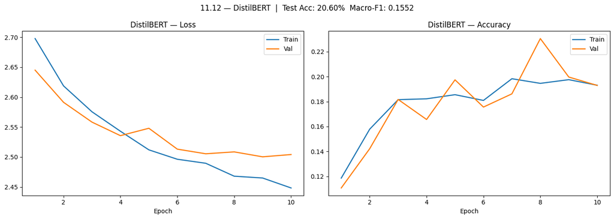

```
  ✓ distilbert_cm.png  →  Colab VM + Drive
```

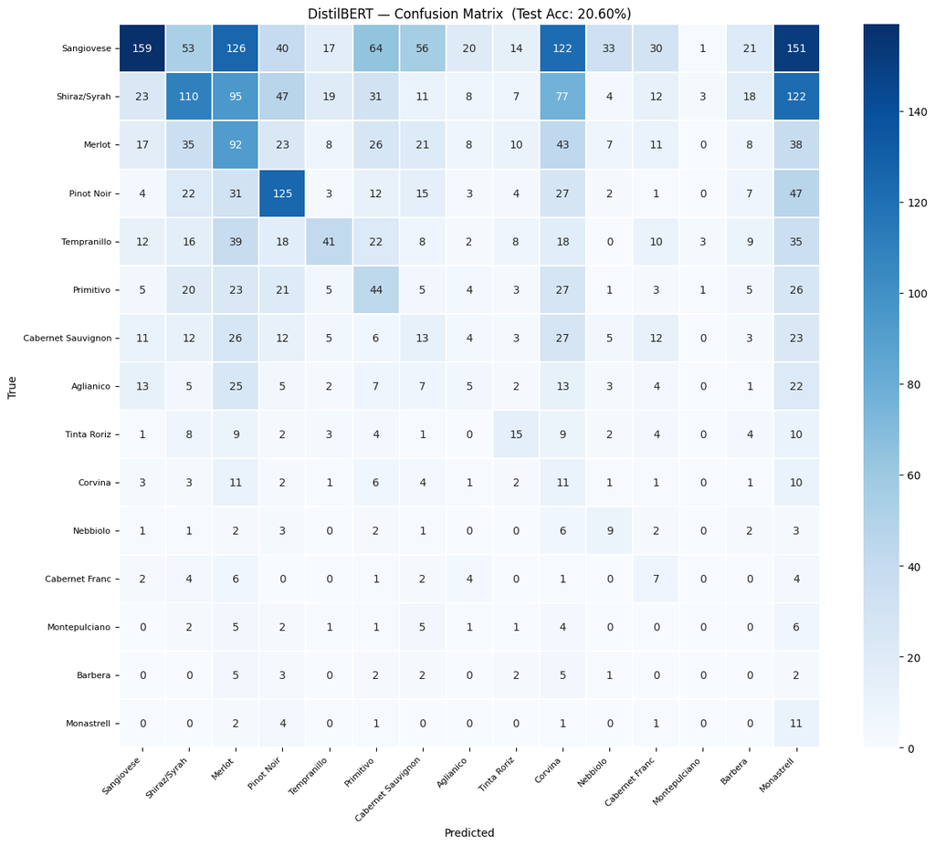

```
======================================================================
Model                            Test Acc    Macro F1    Train Params
----------------------------------------------------------------------
LSTM Baseline                      18.07%      0.1388       1,326,183
BiLSTM + Attention                 21.98%      0.1951       2,878,567
DistilBERT (frozen head)           20.60%      0.1552          11,535
======================================================================
  ✓ text_model_comparison.png  →  Colab VM + Drive
```

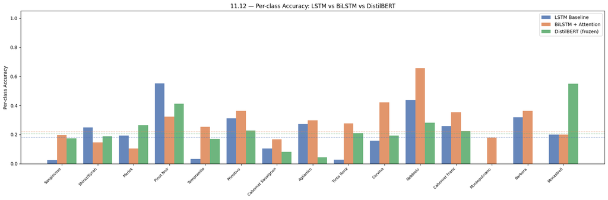

```
✓ Section 11 complete — LSTM, BiLSTM + Attention, and DistilBERT evaluated.
```

```python
# ── 11.12  DistilBERT test evaluation + 3-model comparison ───────────────────
bert_model.load_state_dict(load_checkpoint("distilbert_best.pt"))
bert_model.eval()

all_preds_bert, all_labels_bert = [], []
with torch.no_grad():
    for batch in bert_test_loader:
        ids  = batch["input_ids"].to(DEVICE)
        mask = batch["attention_mask"].to(DEVICE)
        lbls = batch["label"]
        logits = bert_model(ids, mask)
        all_preds_bert.extend(logits.argmax(1).cpu().tolist())
        all_labels_bert.extend(lbls.tolist())

bert_test_acc = sum(p == l for p, l in zip(all_preds_bert, all_labels_bert)) / len(all_labels_bert)
bert_f1       = f1_score(all_labels_bert, all_preds_bert, average="macro")
print(f"DistilBERT (frozen) — Test accuracy : {bert_test_acc:.4f}  ({bert_test_acc*100:.2f}%)")
print(f"                      Macro F1      : {bert_f1:.4f}")
print()
print(classification_report(all_labels_bert, all_preds_bert, target_names=GRAPE_CLASSES, digits=3))

# ── Learning curves ───────────────────────────────────────────────────────────
_epochs_bert = range(1, len(history_bert["train_loss"]) + 1)
fig, axes = plt.subplots(1, 2, figsize=(14, 5))
axes[0].plot(_epochs_bert, history_bert["train_loss"], label="Train", lw=1.8)
axes[0].plot(_epochs_bert, history_bert["val_loss"],   label="Val",   lw=1.8)
axes[0].set_title("DistilBERT — Loss"); axes[0].set_xlabel("Epoch"); axes[0].legend()
axes[1].plot(_epochs_bert, history_bert["train_acc"], label="Train", lw=1.8)
axes[1].plot(_epochs_bert, history_bert["val_acc"],   label="Val",   lw=1.8)
axes[1].set_title("DistilBERT — Accuracy"); axes[1].set_xlabel("Epoch"); axes[1].legend()
plt.suptitle(f"11.12 — DistilBERT  |  Test Acc: {bert_test_acc*100:.2f}%  Macro-F1: {bert_f1:.4f}", fontsize=12)
plt.tight_layout()
save_figure(fig, "distilbert_curves.png")
plt.show()

# ── Confusion matrix ──────────────────────────────────────────────────────────
bert_cm = confusion_matrix(all_labels_bert, all_preds_bert)
fig, ax = plt.subplots(figsize=(13, 11))
sns.heatmap(bert_cm, annot=True, fmt="d", cmap="Blues",
            xticklabels=GRAPE_CLASSES, yticklabels=GRAPE_CLASSES, ax=ax, linewidths=0.3)
ax.set_xlabel("Predicted"); ax.set_ylabel("True")
ax.set_title(f"DistilBERT — Confusion Matrix  (Test Acc: {bert_test_acc*100:.2f}%)")
plt.xticks(rotation=45, ha="right", fontsize=8); plt.yticks(fontsize=8)
plt.tight_layout()
save_figure(fig, "distilbert_cm.png")
plt.show()

# ── 3-model summary table ─────────────────────────────────────────────────────
_lstm_params   = sum(p.numel() for p in lstm_model.parameters())
_bilstm_params = sum(p.numel() for p in bilstm_model.parameters())
_bert_params   = sum(p.numel() for p in bert_model.parameters() if p.requires_grad)

print("\n" + "=" * 70)
print(f"{'Model':<30} {'Test Acc':>10}  {'Macro F1':>10}  {'Train Params':>14}")
print("-" * 70)
print(f"{'LSTM Baseline':<30} {lstm_test_acc*100:>9.2f}%  {lstm_f1:>10.4f}  {_lstm_params:>14,}")
print(f"{'BiLSTM + Attention':<30} {bilstm_test_acc*100:>9.2f}%  {bilstm_f1:>10.4f}  {_bilstm_params:>14,}")
print(f"{'DistilBERT (frozen head)':<30} {bert_test_acc*100:>9.2f}%  {bert_f1:>10.4f}  {_bert_params:>14,}")
print("=" * 70)

# ── Per-class accuracy: 3-model bar chart ─────────────────────────────────────
bert_pca = per_class_acc(all_preds_bert, all_labels_bert, len(GRAPE_CLASSES))
x = range(len(GRAPE_CLASSES)); w = 0.27
fig, ax = plt.subplots(figsize=(18, 6))
ax.bar([i - w     for i in x], lstm_pca,   w, label="LSTM Baseline",       alpha=0.85, color="#4C72B0")
ax.bar([i          for i in x], bilstm_pca, w, label="BiLSTM + Attention",   alpha=0.85, color="#DD8452")
ax.bar([i + w     for i in x], bert_pca,   w, label="DistilBERT (frozen)",  alpha=0.85, color="#55A868")
ax.set_xticks(list(x)); ax.set_xticklabels(GRAPE_CLASSES, rotation=45, ha="right", fontsize=8)
ax.set_ylabel("Per-class Accuracy"); ax.set_ylim(0, 1.05)
ax.axhline(lstm_test_acc,   color="#4C72B0", lw=1.0, ls="--", alpha=0.5)
ax.axhline(bilstm_test_acc, color="#DD8452", lw=1.0, ls="--", alpha=0.5)
ax.axhline(bert_test_acc,   color="#55A868", lw=1.0, ls="--", alpha=0.5)
ax.set_title("11.12 — Per-class Accuracy: LSTM vs BiLSTM vs DistilBERT"); ax.legend()
plt.tight_layout()
save_figure(fig, "text_model_comparison.png")
plt.show()
print("✓ Section 11 complete — LSTM, BiLSTM + Attention, and DistilBERT evaluated.")
```

## Section 12 — TasteBiLSTM: Wine Review Taste Encoder

Trains a dedicated **TasteBiLSTM** model on wine reviews weakly labelled with 10 taste axes. The trained encoder produces a **512-dimensional taste embedding** for any free-text wine review — the foundation of the flavor-cluster recommendation system in Section 14.

| Sub-section | Content |
| --- | --- |
| **12.1** | Taste-label dataset — weak labeling with 10 taste axes; `TasteDataset` and DataLoaders |
| **12.2** | TasteBiLSTM architecture — BiLSTM + Bahdanau attention, 10-dim taste output head |
| **12.3** | Training — Adam, ReduceLROnPlateau, early stopping; saves `tastebilstm_best.pt` |
| **12.4** | Evaluation — per-axis accuracy, precision / recall / F1, learning curves |
| **12.5** | Encoder export — `taste_encoder.encode()` verified on sample reviews |

**Prerequisites:** §4.1 (`df_train/val/test`) · §7.4 (`embedding_matrix`, `X_train/val/test`) · §11.6 (`BahdanauAttention`)

### 12.1 — Taste-Label Dataset

**Weak labeling with 10 taste axes** using keyword matching on lowercased review text:

| Axis | Friendly name | Sample seed words |
| --- | --- | --- |
| `body` | soft | full-bodied, rich, opulent, velvety, dense |
| `acidity` | crispy | acid, crisp, bright, tart, zesty |
| `tannin` | bold | tannin, tannic, grippy, astringent, chewy |
| `red_fruit` | juicy | cherry, raspberry, strawberry, red currant |
| `dark_fruit` | deep | blackberry, plum, cassis, dark fruit, fig |
| `earthy` | earthy | earthy, soil, mushroom, tobacco, leather |
| `sweet` | sweet | sweet, honeyed, jammy, candied, luscious |
| `oaky` | smoky | oak, vanilla, toast, cedar, smoky |
| `floral` | delicate | floral, violet, rose, jasmine, blossom |
| `mineral` | mineral | mineral, minerality, stony, chalk, flinty |

Each review receives a **binary label vector** (dim = 10). A label fires if any seed word appears. Reviews where no axis fires are retained as "neutral" samples — the encoder learns that the absence of taste signals is also informative.

The token sequences `X_train/val/test` (built in §7.4) are reused directly — no re-tokenisation needed.

```python
# ── 12.1  Taste-label dataset ─────────────────────────────────────────────────

# Technical axis names (used in code, model weights, cluster keys)
TASTE_AXES = ["body", "acidity", "tannin", "red_fruit", "dark_fruit",
              "earthy", "sweet",  "oaky",   "floral",    "mineral"]

# User-friendly display names (used in printouts and cluster labels)
TASTE_AXIS_NAMES = {
    "body":       "soft",      # full, round, heavy, velvety
    "acidity":    "crispy",    # crisp, bright, zingy, sharp
    "tannin":     "bold",      # firm, chewy, drying, grippy
    "red_fruit":  "juicy",     # cherry, raspberry, strawberry
    "dark_fruit": "deep",      # plum, blackberry, cassis, fig
    "earthy":     "earthy",    # leather, tobacco, soil, mushroom
    "sweet":      "sweet",     # jammy, soft, warm, generous
    "oaky":       "smoky",     # vanilla, toast, cedar, smoke
    "floral":     "delicate",  # violet, rose, jasmine, blossom
    "mineral":    "mineral",   # flinty, saline, chalky, volcanic
}

_TASTE_KW = {
    "body":       ["full-bodied",  "full bodied",  "rich",        "opulent",
                   "lush",         "concentrated", "powerful",    "dense",
                   "velvety",      "creamy",       "voluminous",  "weighty"],
    "acidity":    ["acid",         "acidity",      "crisp",       "bright",
                   "tart",         "racy",         "lively",      "zesty",
                   "sharp",        "electric",     "refreshing"],
    "tannin":     ["tannin",       "tannic",       "grippy",      "astringent",
                   "firm tannin",  "tight tannin", "chewy",       "drying",
                   "structured",   "gripping"],
    "red_fruit":  ["cherry",       "raspberry",    "strawberry",  "red currant",
                   "cranberry",    "red fruit",    "pomegranate", "redcurrant"],
    "dark_fruit": ["blackberry",   "plum",         "cassis",      "black currant",
                   "dark fruit",   "black fruit",  "blueberry",   "fig",
                   "black cherry", "dark cherry",  "boysenboy",   "mulberry"],
    "earthy":     ["earthy",       "earth",        "soil",        "mushroom",
                   "forest floor", "tobacco",      "leather",     "savory",
                   "herbal",       "truffle",      "barnyard"],
    "sweet":      ["sweet",        "sweetness",    "off-dry",     "residual sugar",
                   "honeyed",      "honey",        "dessert",     "luscious",
                   "syrupy",       "jammy",        "ripe",        "candied",
                   "sugar",        "semi-sweet"],
    "oaky":       ["oak",          "oaky",         "vanilla",     "toast",
                   "toasty",       "cedar",        "smoky",       "barrel",
                   "wood",         "woody",        "buttery",     "spice",
                   "clove",        "coconut",      "caramel"],
    "floral":     ["floral",       "flower",       "violet",      "rose",
                   "jasmine",      "blossom",      "lavender",    "perfumed"],
    "mineral":    ["mineral",      "minerality",   "stony",       "slate",
                   "chalk",        "flinty",       "wet stone",   "limestone",
                   "graphite",     "volcanic",     "flint",       "crushed rock",
                   "steely",       "sea spray",    "oyster shell"],
}


def _taste_label(description: str) -> list:
    """Binary taste labels via keyword matching on lowercased text."""
    d = description.lower()
    return [1.0 if any(kw in d for kw in _TASTE_KW[ax]) else 0.0
            for ax in TASTE_AXES]


# ── Apply to train / val / test ────────────────────────────────────────────────
taste_train = np.array([_taste_label(t) for t in df_train["review_text"]], dtype=np.float32)
taste_val   = np.array([_taste_label(t) for t in df_val["review_text"]],   dtype=np.float32)
taste_test  = np.array([_taste_label(t) for t in df_test["review_text"]],  dtype=np.float32)

# ── Coverage stats — shows both technical and friendly names ───────────────────
print(f"{'Axis':<12} {'Friendly Name':<16} {'train %':>8}  {'val %':>7}  {'test %':>7}")
print("-" * 58)
for i, ax in enumerate(TASTE_AXES):
    tr = taste_train[:, i].mean() * 100
    v  = taste_val[:,   i].mean() * 100
    te = taste_test[:,  i].mean() * 100
    friendly = TASTE_AXIS_NAMES[ax]
    print(f"{ax:<12} {friendly:<16} {tr:>7.1f}%  {v:>6.1f}%  {te:>6.1f}%")

n_neutral = (taste_train.sum(axis=1) == 0).sum()
print(f"\nNeutral (all-zero) reviews : {n_neutral:,} / {len(taste_train):,}  "
      f"({n_neutral/len(taste_train)*100:.1f}%)")
print(f"Avg taste axes per review  : {taste_train.sum(axis=1).mean():.2f}")

# ── Build TasteDataset and DataLoaders ─────────────────────────────────────────
TASTE_BATCH = 64


class TasteDataset(torch.utils.data.Dataset):
    """Wine reviews with multi-label taste annotations."""
    def __init__(self, sequences, taste_labels):
        self.X       = torch.tensor(sequences,    dtype=torch.long)
        self.y       = torch.tensor(taste_labels, dtype=torch.float)   # (N, 10)
        self.lengths = (self.X != 0).sum(dim=1).clamp(min=1)

    def __len__(self):
        return len(self.y)

    def __getitem__(self, i):
        return self.X[i], self.lengths[i], self.y[i]


taste_train_ds = TasteDataset(X_train, taste_train)
taste_val_ds   = TasteDataset(X_val,   taste_val)
taste_test_ds  = TasteDataset(X_test,  taste_test)

taste_train_loader = DataLoader(taste_train_ds, batch_size=TASTE_BATCH, shuffle=True,
                                num_workers=0, pin_memory=False)
taste_val_loader   = DataLoader(taste_val_ds,   batch_size=TASTE_BATCH, shuffle=False,
                                num_workers=0, pin_memory=False)
taste_test_loader  = DataLoader(taste_test_ds,  batch_size=TASTE_BATCH, shuffle=False,
                                num_workers=0, pin_memory=False)

print(f"\n{'Split':<8} {'Samples':>8}  {'Batches':>8}")
print("-" * 28)
for _n, _ds, _ldr in [("train", taste_train_ds, taste_train_loader),
                       ("val",   taste_val_ds,   taste_val_loader),
                       ("test",  taste_test_ds,  taste_test_loader)]:
    print(f"{_n:<8} {len(_ds):>8,}  {len(_ldr):>8,}")

print("\u2713 12.1 \u2014 Taste labels and DataLoaders ready.")
```

```
Axis         Friendly Name     train %    val %   test %
----------------------------------------------------------
body         soft                13.8%    13.2%    12.6%
acidity      crispy              13.5%    13.2%    13.1%
tannin       bold                17.0%    16.6%    16.7%
red_fruit    juicy               23.7%    22.2%    24.1%
dark_fruit   deep                28.2%    26.4%    28.4%
earthy       earthy              15.3%    14.3%    16.8%
sweet        sweet               16.2%    16.8%    15.5%
oaky         smoky               33.1%    33.4%    33.2%
floral       delicate             2.4%     2.2%     3.0%
mineral      mineral              1.6%     1.3%     1.1%

Neutral (all-zero) reviews : 5,117 / 14,537  (35.2%)
Avg taste axes per review  : 1.65

Split     Samples   Batches
----------------------------
train      14,537       228
val         3,115        49
test        3,116        49
✓ 12.1 — Taste labels and DataLoaders ready.
```

### 12.2 — TasteBiLSTM Architecture

```
Input (B × L)  →  Embedding (W2V 100-d, fine-tuned)
               →  Dropout(0.4)
               →  BiLSTM (100-d → 256-d × 2, 2 layers)
               →  Bahdanau attention over all L hidden states  →  B × 512
               →  Dropout(0.4)
               →  Linear(512 → 10)  — one logit per taste axis
```

Identical structure to `BiLSTMAttention` (§11.6) except the output head predicts **10 continuous taste scores** instead of 15 grape classes. The `BahdanauAttention` module from §11.6 is reused directly.

**Training loss:** `BCEWithLogitsLoss` — each axis is an independent binary prediction (a review can be simultaneously tannic, acidic, and rich).

**Encoder output (`encode()`):** the 512-d attention context vector **before** the FC head — this is what §14 uses for flavor-cluster assignment.

| Hyperparameter | Value |
| --- | --- |
| `EMBED_DIM` | 100 (W2V, fine-tuned) |
| `TASTE_HIDDEN` | 256 (= `HIDDEN_DIM`) |
| `N_LAYERS` | 2 |
| `DROPOUT_RNN` | 0.4 |
| Encoder output dim | 512 (`TASTE_HIDDEN × 2`) |

```python
# ── 12.2  TasteBiLSTM architecture ───────────────────────────────────────────
# Reuses BahdanauAttention (defined in §11.6).
# Output head: Linear(512 → 10) — one logit per taste axis.
# encode() returns the 512-d context vector before the FC head.

N_TASTE_AXES = len(TASTE_AXES)   # 10
TASTE_HIDDEN = HIDDEN_DIM        # 256 — same as §11


class TasteBiLSTM(nn.Module):
    def __init__(self, vocab_size, embed_dim, hidden_dim, n_taste=N_TASTE_AXES,
                 n_layers=2, dropout=0.4, embedding_matrix=None):
        super().__init__()
        self.embedding = nn.Embedding(vocab_size, embed_dim, padding_idx=0)
        if embedding_matrix is not None:
            self.embedding.weight.data.copy_(
                torch.tensor(embedding_matrix, dtype=torch.float32))
        self.lstm = nn.LSTM(embed_dim, hidden_dim, num_layers=n_layers,
                            batch_first=True, bidirectional=True,
                            dropout=dropout if n_layers > 1 else 0.0)
        self.attention = BahdanauAttention(hidden_dim)
        self.drop      = nn.Dropout(dropout)
        self.fc        = nn.Linear(hidden_dim * 2, n_taste)

    def forward(self, x, lengths):
        emb    = self.drop(self.embedding(x))
        packed = pack_padded_sequence(emb, lengths.cpu(),
                                      batch_first=True, enforce_sorted=False)
        output, _ = self.lstm(packed)
        output, _ = pad_packed_sequence(output, batch_first=True, total_length=x.shape[1])
        context, _ = self.attention(output, (x != 0))
        return self.fc(self.drop(context))           # (B, 10)

    @torch.no_grad()
    def encode(self, x, lengths):
        """Return 512-d taste context vector — used by §14 (flavor clusters)."""
        emb    = self.embedding(x)
        packed = pack_padded_sequence(emb, lengths.cpu(),
                                      batch_first=True, enforce_sorted=False)
        output, _ = self.lstm(packed)
        output, _ = pad_packed_sequence(output, batch_first=True, total_length=x.shape[1])
        context, _ = self.attention(output, (x != 0))
        return context                               # (B, 512)


taste_bilstm = TasteBiLSTM(
    vocab_size=VOCAB_SIZE, embed_dim=EMBED_DIM, hidden_dim=TASTE_HIDDEN,
    n_taste=N_TASTE_AXES, n_layers=N_LAYERS, dropout=DROPOUT_RNN,
    embedding_matrix=embedding_matrix,
).to(DEVICE)

_total_taste = sum(p.numel() for p in taste_bilstm.parameters())
print(f"TasteBiLSTM — total params : {_total_taste:,}")

_xb_t2, _lb_t2, _yb_t2 = next(iter(taste_train_loader))
_out_taste = taste_bilstm(_xb_t2.to(DEVICE), _lb_t2.to(DEVICE))
assert _out_taste.shape == (TASTE_BATCH, N_TASTE_AXES), \
    f"Expected ({TASTE_BATCH}, {N_TASTE_AXES}), got {_out_taste.shape}"
print(f"Forward pass  : OK → {_out_taste.shape}  (B × {N_TASTE_AXES} taste axes)")

_enc_taste = taste_bilstm.encode(_xb_t2.to(DEVICE), _lb_t2.to(DEVICE))
assert _enc_taste.shape == (TASTE_BATCH, TASTE_HIDDEN * 2)
print(f"encode()      : OK → {_enc_taste.shape}  (B × {TASTE_HIDDEN * 2}-d taste embedding)")
print("✓ 12.2 — TasteBiLSTM ready.")
```

```
TasteBiLSTM — total params : 2,876,002
Forward pass  : OK → torch.Size([64, 10])  (B × 10 taste axes)
encode()      : OK → torch.Size([64, 512])  (B × 512-d taste embedding)
✓ 12.2 — TasteBiLSTM ready.
```

### 12.3 — Training TasteBiLSTM

Same protocol as §11.4 / §11.7:

| Setting | Value |
| --- | --- |
| Optimiser | Adam, lr = 1e-3, weight_decay = 1e-5 |
| LR scheduler | ReduceLROnPlateau × 0.5, patience 2 |
| Max epochs | 30 |
| Early stopping | patience = 4 |
| Gradient clipping | max-norm 5 |
| Loss | `BCEWithLogitsLoss` (multi-label) |

Per-epoch checkpoints saved as `tastebilstm_ckpt_epXX.pt` to allow resume after disconnection. Best model (lowest val loss) saved to `tastebilstm_best.pt`.

```python
# ── 12.3  Train TasteBiLSTM ───────────────────────────────────────────────────
TASTE_EPOCHS   = 30
TASTE_PATIENCE = 4

# ── Class-imbalance correction via pos_weight ─────────────────────────────────
# floral=2.4%, mineral=1.7% are severely under-represented.
# pos_weight[i] = neg_count / pos_count  (capped at 20 to prevent loss instability).
_pos_counts  = taste_train.sum(axis=0).clip(min=1)          # (10,) float32
_neg_counts  = len(taste_train) - _pos_counts
_pw_raw      = _neg_counts / _pos_counts
_pw_capped   = np.minimum(_pw_raw, 20.0)
pos_weight_t = torch.tensor(_pw_capped, dtype=torch.float32, device=DEVICE)
print(f"{'Axis':<16}  {'pos%':>5}  {'pos_weight':>10}")
print("-" * 36)
for ax, pw, pct in zip(TASTE_AXES, _pw_capped, _pos_counts / len(taste_train) * 100):
    print(f"{ax:<16}  {pct:>5.1f}  {pw:>10.2f}")
print()

criterion_taste = nn.BCEWithLogitsLoss(pos_weight=pos_weight_t)
opt_taste       = Adam(taste_bilstm.parameters(), lr=1e-3, weight_decay=1e-5)
sched_taste     = ReduceLROnPlateau(opt_taste, factor=0.5, patience=2)

history_taste       = {"train_loss": [], "val_loss": [], "train_acc": [], "val_acc": []}
best_val_loss_taste = float("inf")
no_improve_taste    = 0


def _train_taste_epoch(model, loader, criterion, optimizer):
    model.train()
    total_loss, correct, n = 0.0, 0, 0
    for seqs, lengths, labels in loader:
        seqs, lengths, labels = seqs.to(DEVICE), lengths.to(DEVICE), labels.to(DEVICE)
        optimizer.zero_grad()
        logits = model(seqs, lengths)
        loss   = criterion(logits, labels)
        loss.backward()
        torch.nn.utils.clip_grad_norm_(model.parameters(), 5.0)
        optimizer.step()
        preds       = (logits.sigmoid() >= 0.5).float()
        correct     += (preds == labels).all(dim=1).sum().item()
        total_loss  += loss.item() * len(seqs)
        n           += len(seqs)
    return total_loss / n, correct / n


def _eval_taste(model, loader, criterion):
    model.eval()
    total_loss, correct, n = 0.0, 0, 0
    with torch.no_grad():
        for seqs, lengths, labels in loader:
            seqs, lengths, labels = seqs.to(DEVICE), lengths.to(DEVICE), labels.to(DEVICE)
            logits = model(seqs, lengths)
            loss   = criterion(logits, labels)
            preds  = (logits.sigmoid() >= 0.5).float()
            correct    += (preds == labels).all(dim=1).sum().item()
            total_loss += loss.item() * len(seqs)
            n          += len(seqs)
    return total_loss / n, correct / n


print(f"Training TasteBiLSTM  (max {TASTE_EPOCHS} epochs, patience={TASTE_PATIENCE})")
print(f"{'Epoch':>5}  {'tr_loss':>8}  {'tr_acc':>7}  {'vl_loss':>8}  {'vl_acc':>7}  {'lr':>9}")
print("-" * 57)

for epoch in range(1, TASTE_EPOCHS + 1):
    tr_loss, tr_acc = _train_taste_epoch(taste_bilstm, taste_train_loader, criterion_taste, opt_taste)
    vl_loss, vl_acc = _eval_taste(taste_bilstm, taste_val_loader, criterion_taste)
    history_taste["train_loss"].append(tr_loss)
    history_taste["val_loss"].append(vl_loss)
    history_taste["train_acc"].append(tr_acc)
    history_taste["val_acc"].append(vl_acc)
    sched_taste.step(vl_loss)
    lr_now = opt_taste.param_groups[0]["lr"]
    if vl_loss < best_val_loss_taste:
        best_val_loss_taste = vl_loss
        no_improve_taste    = 0
        save_checkpoint(taste_bilstm.state_dict(), "tastebilstm_best.pt")
        marker = " ✓"
    else:
        no_improve_taste += 1
        marker = ""
    save_checkpoint(
        {"epoch": epoch, "model_state": taste_bilstm.state_dict(),
         "optimizer_state": opt_taste.state_dict(), "val_loss": vl_loss,
         "history": history_taste},
        f"tastebilstm_ckpt_ep{epoch:02d}.pt"
    )
    print(f"{epoch:>5}  {tr_loss:>8.4f}  {tr_acc:>7.4f}  {vl_loss:>8.4f}  {vl_acc:>7.4f}  {lr_now:>9.2e}{marker}")
    if no_improve_taste >= TASTE_PATIENCE:
        print(f"\nEarly stopping at epoch {epoch}.")
        break

print(f"\nBest val loss : {best_val_loss_taste:.4f}  →  {WEIGHTS / 'tastebilstm_best.pt'}")
print("✓ 12.3 — TasteBiLSTM training complete.")
```

```
Axis               pos%  pos_weight
------------------------------------
body               13.8        6.23
acidity            13.5        6.42
tannin             17.0        4.88
red_fruit          23.7        3.23
dark_fruit         28.2        2.55
earthy             15.3        5.52
sweet              16.2        5.18
oaky               33.1        2.02
floral              2.4       20.00
mineral             1.6       20.00

Training TasteBiLSTM  (max 30 epochs, patience=4)
Epoch   tr_loss   tr_acc   vl_loss   vl_acc         lr
---------------------------------------------------------
  ✓ tastebilstm_best.pt  →  Colab VM + Drive
  ✓ tastebilstm_ckpt_ep01.pt  →  Colab VM + Drive
    1    0.7287   0.3179    0.5144   0.4398   1.00e-03 ✓
  ✓ tastebilstm_best.pt  →  Colab VM + Drive
  ✓ tastebilstm_ckpt_ep02.pt  →  Colab VM + Drive
    2    0.4522   0.4696    0.2951   0.5778   1.00e-03 ✓
  ✓ tastebilstm_best.pt  →  Colab VM + Drive
  ✓ tastebilstm_ckpt_ep03.pt  →  Colab VM + Drive
    3    0.2708   0.6613    0.1750   0.7913   1.00e-03 ✓
  ✓ tastebilstm_best.pt  →  Colab VM + Drive
  ✓ tastebilstm_ckpt_ep04.pt  →  Colab VM + Drive
    4    0.1819   0.7830    0.1357   0.8909   1.00e-03 ✓
  ✓ tastebilstm_best.pt  →  Colab VM + Drive
  ✓ tastebilstm_ckpt_ep05.pt  →  Colab VM + Drive
    5    0.1399   0.8401    0.1180   0.8690   1.00e-03 ✓
  ✓ tastebilstm_best.pt  →  Colab VM + Drive
  ✓ tastebilstm_ckpt_ep06.pt  →  Colab VM + Drive
    6    0.1139   0.8688    0.1084   0.9140   1.00e-03 ✓
  ✓ tastebilstm_best.pt  →  Colab VM + Drive
  ✓ tastebilstm_ckpt_ep07.pt  →  Colab VM + Drive
    7    0.0933   0.8930    0.1005   0.9364   1.00e-03 ✓
  ✓ tastebilstm_ckpt_ep08.pt  →  Colab VM + Drive
    8    0.0778   0.9091    0.1147   0.9390   1.00e-03
  ✓ tastebilstm_ckpt_ep09.pt  →  Colab VM + Drive
    9    0.0697   0.9192    0.1061   0.9467   1.00e-03
  ✓ tastebilstm_ckpt_ep10.pt  →  Colab VM + Drive
   10    0.0620   0.9244    0.1176   0.9474   5.00e-04
  ✓ tastebilstm_ckpt_ep11.pt  →  Colab VM + Drive
   11    0.0466   0.9450    0.1131   0.9480   5.00e-04

Early stopping at epoch 11.

Best val loss : 0.1005  →  weights/tastebilstm_best.pt
✓ 12.3 — TasteBiLSTM training complete.
```

### 12.4 — Evaluation

Loads the best checkpoint and runs inference on the frozen test set. Each of the 10 taste axes is treated as an independent binary prediction.

| Metric | Description |
| --- | --- |
| **Accuracy** | Fraction of reviews correctly classified for this axis |
| **Precision / Recall / F1** | Standard binary classification metrics per axis |
| **Exact-match accuracy** | All 10 axes correct simultaneously (strictest metric) |

```
  → Loading from VM: weights/tastebilstm_best.pt
Axis         Friendly          Thr      Acc    Prec     Rec      F1
--------------------------------------------------------------------
body         soft             0.50   0.9933  0.9696  0.9770  0.9733
acidity      crispy           0.50   0.9785  0.8778  0.9705  0.9218
tannin       bold             0.50   0.9852  0.9421  0.9711  0.9564
red_fruit    juicy            0.50   0.9901  0.9787  0.9800  0.9794
dark_fruit   deep             0.50   0.9856  0.9827  0.9661  0.9743
earthy       earthy           0.50   0.9952  0.9942  0.9771  0.9856
sweet        sweet            0.50   0.9907  0.9809  0.9585  0.9696
oaky         smoky            0.50   0.9881  0.9931  0.9710  0.9819
floral       delicate         0.50   0.9968  0.9770  0.9140  0.9444
mineral      mineral          0.55   0.9949  0.7111  0.9143  0.8000

Macro F1 (avg over axes) : 0.9487
Exact-match accuracy     : 0.9291
  ✓ tastebilstm_curves.png  →  Colab VM + Drive
```

[figure not shown]

```
  ✓ tastebilstm_axis_f1.png  →  Colab VM + Drive
```

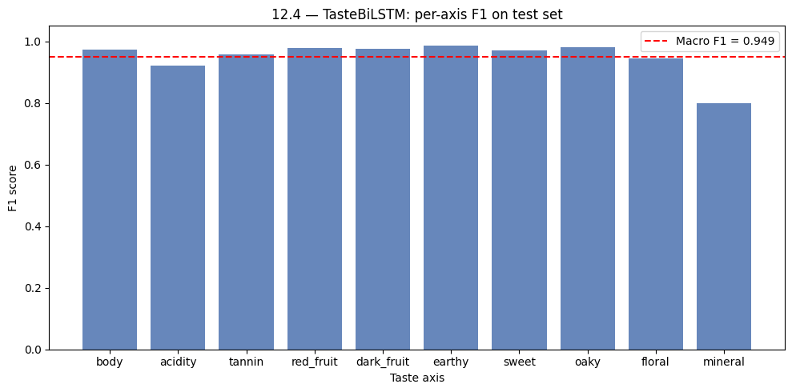

```
✓ 12.4 — TasteBiLSTM evaluation complete.
```

```python
# ── 12.4  TasteBiLSTM — test evaluation ─────────────────────────────────────────────────────
from sklearn.metrics import precision_score, recall_score

taste_bilstm.load_state_dict(load_checkpoint("tastebilstm_best.pt"))
taste_bilstm.eval()

all_probs_taste, all_labels_taste = [], []
with torch.no_grad():
    for seqs, lengths, labels in taste_test_loader:
        logits = taste_bilstm(seqs.to(DEVICE), lengths.to(DEVICE))
        all_probs_taste.append(logits.sigmoid().cpu())
        all_labels_taste.append(labels)

all_probs_taste  = torch.cat(all_probs_taste,  dim=0)
all_labels_taste = torch.cat(all_labels_taste, dim=0)

# Fix 3 — per-axis thresholds.
# (historical: citrus_fruity had recall 0.36 at 0.50 in v1 with 8 axes) → lowered to 0.35 to catch more positives.
# mineral had precision 0.65 at 0.50 (too many false positives) → raised to 0.55.
_AXIS_THRESHOLDS = torch.tensor([
    0.50,  # body
    0.50,  # acidity
    0.50,  # tannin
    0.50,  # red_fruit
    0.50,  # dark_fruit
    0.50,  # earthy
    0.50,  # sweet
    0.50,  # oaky
    0.50,  # floral
    0.55,  # mineral     ← raised: over-predicted in v1 (precision 0.65)
])
all_preds_taste = (all_probs_taste >= _AXIS_THRESHOLDS).float()

# ── Per-axis accuracy, precision, recall, F1 ───────────────────────────────────────────────
print(f"{'Axis':<12} {'Friendly':<16} {'Thr':>4}  {'Acc':>7}  {'Prec':>6}  {'Rec':>6}  {'F1':>6}")
print("-" * 68)
taste_axis_f1s = []
for i, ax in enumerate(TASTE_AXES):
    y_true   = all_labels_taste[:, i].numpy()
    y_pred   = all_preds_taste[:,  i].numpy()
    acc      = (y_true == y_pred).mean()
    prec     = precision_score(y_true, y_pred, zero_division=0)
    rec      = recall_score(y_true,    y_pred, zero_division=0)
    f1_ax    = f1_score(y_true,        y_pred, zero_division=0)
    taste_axis_f1s.append(f1_ax)
    thr      = _AXIS_THRESHOLDS[i].item()
    friendly = TASTE_AXIS_NAMES[ax]
    print(f"{ax:<12} {friendly:<16} {thr:>4.2f}  {acc:>7.4f}  {prec:>6.4f}  {rec:>6.4f}  {f1_ax:>6.4f}")

macro_taste_f1 = np.mean(taste_axis_f1s)
exact_match    = (all_preds_taste == all_labels_taste).all(dim=1).float().mean().item()
print(f"\nMacro F1 (avg over axes) : {macro_taste_f1:.4f}")
print(f"Exact-match accuracy     : {exact_match:.4f}")

# ── Learning curves ──────────────────────────────────────────────────────────────────────────
_epochs_taste = range(1, len(history_taste["train_loss"]) + 1)
fig, axes = plt.subplots(1, 2, figsize=(14, 5))
axes[0].plot(_epochs_taste, history_taste["train_loss"], label="Train", lw=1.8)
axes[0].plot(_epochs_taste, history_taste["val_loss"],   label="Val",   lw=1.8)
axes[0].set_title("TasteBiLSTM — Loss"); axes[0].set_xlabel("Epoch"); axes[0].legend()
axes[1].plot(_epochs_taste, history_taste["train_acc"], label="Train", lw=1.8)
axes[1].plot(_epochs_taste, history_taste["val_acc"],   label="Val",   lw=1.8)
axes[1].set_title("TasteBiLSTM — Exact-match Accuracy")
axes[1].set_xlabel("Epoch"); axes[1].legend()
plt.suptitle(
    f"12.4 — TasteBiLSTM  |  Macro-F1: {macro_taste_f1:.4f}  "
    f"Exact-match: {exact_match*100:.2f}%", fontsize=12)
plt.tight_layout()
save_figure(fig, "tastebilstm_curves.png")
plt.show()

# ── Per-axis F1 bar chart ────────────────────────────────────────────────────────────────────────
fig, ax = plt.subplots(figsize=(10, 5))
ax.bar(TASTE_AXES, taste_axis_f1s, color="#4C72B0", alpha=0.85)
ax.axhline(macro_taste_f1, color="red", lw=1.5, ls="--",
           label=f"Macro F1 = {macro_taste_f1:.3f}")
ax.set_xlabel("Taste axis"); ax.set_ylabel("F1 score"); ax.set_ylim(0, 1.05)
ax.set_title("12.4 — TasteBiLSTM: per-axis F1 on test set")
ax.legend(); plt.tight_layout()
save_figure(fig, "tastebilstm_axis_f1.png")
plt.show()
print("✓ 12.4 — TasteBiLSTM evaluation complete.")
```

### 12.5 — Encoder Export

Exports `taste_encoder` (alias for `taste_bilstm`) as the global handle used by **Section 14 — Flavor-Cluster Recommendation**.

`taste_encoder.encode(x, lengths)` returns a `Tensor(B, 512)` — the Bahdanau attention context vector computed **before** the FC head. It requires no gradient and runs in eval mode. Section 14 calls this on the full wine corpus to build flavor-cluster centroids.

```python
# ── 12.5  Encoder export ──────────────────────────────────────────────────────
# taste_encoder is the global handle used by Section 14 (flavor clusters).
# encode(x, lengths) → (B, 512) float tensor — no grad, eval mode.

taste_encoder = taste_bilstm
taste_encoder.eval()

# ── Sanity check: shape and variability ───────────────────────────────────────
_sample_seqs, _sample_lens, _ = next(iter(taste_test_loader))
_sample_embs = taste_encoder.encode(_sample_seqs.to(DEVICE), _sample_lens.to(DEVICE))
print(f"encode() output shape : {_sample_embs.shape}")      # expected (64, 512)
print(f"Embedding norm (mean) : {_sample_embs.norm(dim=1).mean().item():.4f}")
print(f"Embedding std  (mean) : {_sample_embs.std(dim=0).mean().item():.4f}")

# ── Sample reviews → predicted taste profile ──────────────────────────────────
print("\nSample reviews → predicted taste profile:")
print("-" * 70)
_sample_logits = taste_bilstm(_sample_seqs.to(DEVICE), _sample_lens.to(DEVICE))
_sample_preds  = (_sample_logits.sigmoid() >= 0.5).cpu().numpy()
for i in range(5):
    desc_short  = df_test["review_text"].iloc[i][:80].replace("\n", " ")
    active_axes = [TASTE_AXES[j] for j, v in enumerate(_sample_preds[i]) if v]
    print(f"[{i+1}] \"{desc_short}...\"")
    print(f"     → {active_axes if active_axes else ['(neutral)']}\n")

print("✓ Section 12 complete — TasteBiLSTM encoder ready → taste_encoder")
```

```
encode() output shape : torch.Size([64, 512])
Embedding norm (mean) : 10.3215
Embedding std  (mean) : 0.3753

Sample reviews → predicted taste profile:
----------------------------------------------------------------------
[1] "3.9 Fair Enough for a daily basis wine ..."
     → ['(neutral)']

[2] "Black fruit red fruit vanilla boomboompow..."
     → ['red_fruit', 'dark_fruit', 'oaky']

[3] "Dry with strong fruit note Rasbery and blueberry. ..."
     → ['dark_fruit']

[4] "Wow for the price. Heavy oak, rich dark purple colour. Bold and smooth...."
     → ['body', 'oaky']

[5] "vanilla chocolate oak blackberry cherry leather ..."
     → ['red_fruit', 'dark_fruit', 'earthy', 'oaky']

✓ Section 12 complete — TasteBiLSTM encoder ready → taste_encoder
```

## Section 13 — Save All Results and Weights

Persists every trained model's weights, predictions, metrics, and training history to disk. On Colab, all files are also synced to Google Drive so nothing is lost on session restart.

| Model | Weight file | Trained in |
| --- | --- | --- |
| CNN from scratch | `cnn_scratch_best.pt` | §8 |
| ResNet-50 (transfer learning) | `cnn_resnet50_best.pt` | §9 |
| LSTM Baseline | `lstm_best.pt` | §11 |
| BiLSTM + Attention | `bilstm_best.pt` | §11 |
| DistilBERT (frozen head) | `distilbert_best.pt` | §11 |
| TasteBiLSTM (taste encoder) | `tastebilstm_best.pt` | §12 |

```python
# ── 13  Save ALL results ──────────────────────────────────────────────────────
# glob, shutil, os, torch, np already imported in §1.2.
# save_checkpoint / load_checkpoint / save_figure defined in §1.3.
import glob, pickle

# ── Build snapshot ────────────────────────────────────────────────────────────
snapshot = {
    # §8 — CNN from scratch
    "cnn_scratch": {
        "test_acc":        globals().get("test_acc"),
        "macro_f1":        globals().get("macro_f1"),
        "history":         globals().get("history_scratch"),
        "confusion_matrix":globals().get("sc_cm"),
        "weights_file":    "cnn_scratch_best.pt",
    },
    # §9 — ResNet-50 transfer learning
    "resnet50": {
        "test_acc":        globals().get("rn_test_acc"),
        "macro_f1":        globals().get("rn_f1"),
        "history":         globals().get("hist_rn"),
        "confusion_matrix":globals().get("cm"),
        "weights_file":    "cnn_resnet50_best.pt",
    },
    # §11 — LSTM Baseline
    "lstm": {
        "test_acc":        globals().get("lstm_test_acc"),
        "macro_f1":        globals().get("lstm_f1"),
        "history":         globals().get("history_lstm"),
        "confusion_matrix":globals().get("lstm_cm"),
        "weights_file":    "lstm_best.pt",
    },
    # §11 — BiLSTM + Attention
    "bilstm": {
        "test_acc":        globals().get("bilstm_test_acc"),
        "macro_f1":        globals().get("bilstm_f1"),
        "history":         globals().get("history_bilstm"),
        "confusion_matrix":globals().get("bilstm_cm"),
        "weights_file":    "bilstm_best.pt",
    },
    # §11 — DistilBERT (frozen head)
    "distilbert": {
        "test_acc":        globals().get("bert_test_acc"),
        "macro_f1":        globals().get("bert_f1"),
        "history":         globals().get("history_bert"),
        "confusion_matrix":globals().get("bert_cm"),
        "weights_file":    "distilbert_best.pt",
    },
    # §12 — TasteBiLSTM (taste encoder)
    "tastebilstm": {
        "macro_f1":        globals().get("macro_taste_f1"),
        "exact_match":     globals().get("exact_match"),
        "axis_f1s":        globals().get("taste_axis_f1s"),
        "history":         globals().get("history_taste"),
        "weights_file":    "tastebilstm_best.pt",
    },
    # Shared text artefacts
    "text": {
        "VOCAB_SIZE":      globals().get("VOCAB_SIZE"),
        "MAX_SEQ_LEN":     globals().get("MAX_SEQ_LEN"),
        "GRAPE_CLASSES":   globals().get("GRAPE_CLASSES"),
        "GRAPE_TO_IDX":    globals().get("GRAPE_TO_IDX"),
        "TASTE_AXES":      globals().get("TASTE_AXES"),
        "embedding_matrix":globals().get("embedding_matrix"),
    },
    # Dataset provenance
    "splits": {
        "SEED":       SEED,
        "n_train_text": len(df_train) if "df_train" in globals() else None,
        "n_val_text":   len(df_val)   if "df_val"   in globals() else None,
        "n_test_text":  len(df_test)  if "df_test"  in globals() else None,
        "n_train_img":  len(_idx_train) if "_idx_train" in globals() else None,
        "n_val_img":    len(_idx_val)   if "_idx_val"   in globals() else None,
        "n_test_img":   len(_idx_test)  if "_idx_test"  in globals() else None,
    },
}


# ── Sanitise: convert tensors / arrays → plain Python; drop unpicklable objects
def _sanitize(obj, _depth=0):
    if _depth > 12:
        return None
    if obj is None or isinstance(obj, (bool, int, float, str)):
        return obj
    if isinstance(obj, torch.Tensor):
        return obj.detach().cpu().tolist()
    if isinstance(obj, np.ndarray):
        return obj.tolist()
    if isinstance(obj, dict):
        return {k: _sanitize(v, _depth + 1) for k, v in obj.items()}
    if isinstance(obj, (list, tuple)):
        return [_sanitize(v, _depth + 1) for v in obj]
    try:
        pickle.dumps(obj)
        return obj
    except Exception:
        return None   # silently drop modules, lambdas, etc.


safe_snapshot = _sanitize(snapshot)

# ── 1. Save snapshot ──────────────────────────────────────────────────────────
snap_path = LOCAL_WEIGHTS / "results_snapshot.pt"
torch.save(safe_snapshot, snap_path)
print(f"✓ results_snapshot.pt  ({snap_path.stat().st_size / 1e6:.1f} MB)")
if IN_COLAB:
    shutil.copy2(snap_path, os.path.join(WEIGHTS_DIR, "results_snapshot.pt"))
    print(f"  → synced to Drive: {WEIGHTS_DIR}")

# ── 2. Sync weight files ──────────────────────────────────────────────────────
WEIGHT_FILES = [
    "cnn_scratch_best.pt",
    "cnn_resnet50_best.pt",
    "lstm_best.pt",
    "bilstm_best.pt",
    "distilbert_best.pt",
    "tastebilstm_best.pt",
]

print("\nWeight files:")
for wf in WEIGHT_FILES:
    src = LOCAL_WEIGHTS / wf
    if src.exists():
        mb = src.stat().st_size / 1e6
        if IN_COLAB:
            shutil.copy2(src, os.path.join(WEIGHTS_DIR, wf))
            print(f"  ✓ {wf:<35} {mb:.1f} MB  → Drive")
        else:
            print(f"  ✓ {wf:<35} {mb:.1f} MB")
    else:
        print(f"  ✗ {wf:<35} NOT FOUND")

# ── 3. Sync figures ───────────────────────────────────────────────────────────
local_pngs = sorted(LOCAL_FIGURES.glob("*.png"))
if IN_COLAB:
    synced = 0
    for p in local_pngs:
        dest = os.path.join(FIGURES_DIR, p.name)
        if not os.path.exists(dest) or os.path.getsize(dest) != p.stat().st_size:
            shutil.copy2(p, dest)
            synced += 1
    print(f"\nFigures: {synced} synced to Drive  ({len(local_pngs) - synced} already up-to-date)")
else:
    print(f"\nFigures: {len(local_pngs)} saved locally in figures/")

# ── 4. Summary table ──────────────────────────────────────────────────────────
print("\n" + "=" * 75)
print(f"  {'Model':<30} {'Test Acc':>10}  {'Macro F1':>10}  Weight file")
print("-" * 75)

def _fmt(v, pct=False):
    if v is None:
        return "n/a"
    return f"{v*100:.2f}%" if pct else f"{v:.4f}"

_rows = [
    ("CNN from scratch",          snapshot["cnn_scratch"]["test_acc"],  snapshot["cnn_scratch"]["macro_f1"],  "cnn_scratch_best.pt"),
    ("ResNet-50 transfer",        snapshot["resnet50"]["test_acc"],     snapshot["resnet50"]["macro_f1"],     "cnn_resnet50_best.pt"),
    ("LSTM Baseline",             snapshot["lstm"]["test_acc"],         snapshot["lstm"]["macro_f1"],         "lstm_best.pt"),
    ("BiLSTM + Attention",        snapshot["bilstm"]["test_acc"],       snapshot["bilstm"]["macro_f1"],       "bilstm_best.pt"),
    ("DistilBERT (frozen head)",  snapshot["distilbert"]["test_acc"],   snapshot["distilbert"]["macro_f1"],   "distilbert_best.pt"),
    ("TasteBiLSTM (encoder)",     None,                                  snapshot["tastebilstm"]["macro_f1"], "tastebilstm_best.pt"),
]
for name, acc, f1, wf in _rows:
    print(f"  {name:<30} {_fmt(acc, pct=True):>10}  {_fmt(f1):>10}  {wf}")

print("=" * 75)
print(f"\n  TasteBiLSTM exact-match accuracy : {_fmt(snapshot['tastebilstm']['exact_match'])}")
print("\n✓ Section 13 complete — all results saved.")
```

```
✓ results_snapshot.pt  (3.9 MB)
  → synced to Drive: /content/drive/MyDrive/wine-dine/weights

Weight files:
  ✓ cnn_scratch_best.pt                 23.2 MB  → Drive
  ✓ cnn_resnet50_best.pt                95.2 MB  → Drive
  ✓ lstm_best.pt                        5.3 MB  → Drive
  ✓ bilstm_best.pt                      11.5 MB  → Drive
  ✓ distilbert_best.pt                  265.5 MB  → Drive
  ✓ tastebilstm_best.pt                 11.5 MB  → Drive

Figures: 1 synced to Drive  (32 already up-to-date)

===========================================================================
  Model                            Test Acc    Macro F1  Weight file
---------------------------------------------------------------------------
  CNN from scratch                   48.28%      0.4672  cnn_scratch_best.pt
  ResNet-50 transfer                 77.23%      0.7714  cnn_resnet50_best.pt
  LSTM Baseline                      18.07%      0.1388  lstm_best.pt
  BiLSTM + Attention                 21.98%      0.1951  bilstm_best.pt
  DistilBERT (frozen head)           20.60%      0.1552  distilbert_best.pt
  TasteBiLSTM (encoder)                 n/a      0.9487  tastebilstm_best.pt
===========================================================================

  TasteBiLSTM exact-match accuracy : 0.9291

✓ Section 13 complete — all results saved.
```

## Section 14 — Flavor-Cluster Recommendation

> **This is the core ML product of the project.** Everything before this section trained models. This section *uses* those models to solve a real recommendation problem — matching food to wine via a shared taste embedding space, with no hardcoded rules and full confidence transparency.

The previous sections produced two trained encoders:

- **BiLSTMAttention** (§11) — encodes wine reviews into 512-d grape-space vectors
- **TasteBiLSTM** (§12) — encodes wine reviews into 512-d taste-space vectors

### ML techniques in this section

[output not shown]

### Food flavor descriptions

Source: `food_flavor_description_v2.json` (101 entries, 3 keys each):

| JSON key | Card tier | Icon | Meaning |
| --- | --- | --- | --- |
| `classic` | SAFE BET | ✅ | Dominant flavor identity — closest taste match |
| `safe_bet` | HIDDEN GEM | 💎 | Compatible but surprising — pairs unexpectedly well |
| `contrast` | *(not used)* | — | Bold Move is taste-aware geometric, not description-based |

**Prerequisites:** §3.4 (`food_flavor_table_v2`), §7 (`VOCAB`, `MAX_SEQ_LEN`, `X_train`), §12 (`taste_encoder`)

### Sub-sections

| # | Content |
| --- | --- |
| 14.1 | Encode wine corpus → `train_taste_vecs` (N × 512) |
| 14.2 | Silhouette curve K=6–20, fit BisectingKMeans K=9 |
| 14.3 | Auto-name clusters via TF-IDF + taste-axis naming |
| 14.4 | Select top-10 wine pool per cluster (with taste vectors) |
| 14.5 | `recommend_v2()` — food-specific wine selection + confidence scoring |
| 14.6 | Full 101-food evaluation + diversity stats |
| 14.7 | Business integration: 20-food recommendation table |
| 14.8 | Model performance comparison chart |

### 14.1 — Encode Wine Corpus

Encode every training wine review through `taste_encoder.encode()` in batches of 256. Input: `X_train` — already tokenized and zero-padded in §7 (shape N_train × MAX_SEQ_LEN). Output: `train_taste_vecs` (N_train × 512), L2-normalised for cosine-correct K-means.

```python
# ── 14.1  Encode wine corpus through taste_encoder ───────────────────────────
import torch
import numpy as np

ENCODE_BATCH = 256
taste_encoder.eval()

print("Encoding training wine reviews through taste_encoder …")
X_train_t   = torch.tensor(X_train, dtype=torch.long)   # (N_train, MAX_SEQ_LEN)
N_train_all = len(X_train_t)
all_vecs    = []

for start in range(0, N_train_all, ENCODE_BATCH):
    batch   = X_train_t[start : start + ENCODE_BATCH].to(DEVICE)
    lengths = (batch != 0).sum(dim=1).clamp(min=1)
    with torch.no_grad():
        vecs = taste_encoder.encode(batch, lengths)        # (B, 512)
    all_vecs.append(vecs.cpu().numpy())
    done = min(start + ENCODE_BATCH, N_train_all)
    if (start // ENCODE_BATCH) % 20 == 0 or done == N_train_all:
        print(f"  encoded {done:>6,}/{N_train_all:,}", end="\r")

print()
raw_norms        = np.linalg.norm(np.vstack(all_vecs), axis=1)
train_taste_vecs = np.vstack(all_vecs) / raw_norms[:, None]    # L2-normalise → (N, 512)

print(f"train_taste_vecs  shape : {train_taste_vecs.shape}")
print(f"  pre-norm  min={raw_norms.min():.4f}  mean={raw_norms.mean():.4f}  max={raw_norms.max():.4f}")
print("✓ Section 14.1 complete — train_taste_vecs ready.")
```

```
Encoding training wine reviews through taste_encoder …
  encoded 14,537/14,537
train_taste_vecs  shape : (14537, 512)
  pre-norm  min=2.8675  mean=10.1913  max=14.2105
```